# Ancestry callers compared — MolB-RTI, Skim-RTI, and Skim-BIN

Author

Fausto Rodríguez-Zapata

Published

June 26, 2026

**Repo:** sawers-rellan-labs/zealtiger

Three ancestry call sets on the **same 16 BZea lines**, painted side by side:

- **MolB-RTI (r=2)** — MolBreeding ~110× target-capture sequencing, RTIGER at the truth-derived rigidity (`docs/15-rigidity-and-scoring.md`).
- **Skim-RTI (r=5)** — SNP50K ~0.4× skim, RTIGER at the truth-derived rigidity.
- **Skim-BIN** — the BzeaSeq caller on the **same skim reads** (1 Mb bins, Gaussian mixture on `ALT_FREQ`, then HMM-smoothed; `BzeaSeq/docs/call_ancestry.Rmd`).

This is the companion to the two-way `molbreeding_vs_skim_calibrated.qmd` (which is MolB-RTI vs Skim-RTI only). The point here is to add an **independent skim caller** (Skim-BIN) and ask whether the MolB-vs-Skim gap is a RTIGER artifact or a platform effect. Palette follows the BzeaSeq convention: `REF` gold, `HET` springgreen4, `ALT` purple4. Calls are segments on B73 NAM v5 (0/REF, 1/HET, 2/ALT). The two B73-bulk checks (`PN4_SID326`, `PN6_SID576`) have no Skim-RTI lane (MolB-only).

**Naming (source × caller).** Call sets are labelled `Source-Caller`. Sources: **Skim** (SNP50K ~0.4× skim reads), **MolB** (MolBreeding target-capture sequencing ~110×). Callers: **RTI** = RTIGER (per-marker HMM); **BIN** = BzeaSeq 1 Mb-bin GMM-HMM. So the three lanes are **MolB-RTI (r=2)**, **Skim-RTI (r=5)** and **Skim-BIN** — `Skim-RTI` and `Skim-BIN` are the *same skim reads* through different filters + callers (50K-SNP RTIGER vs 27M→1 Mb-bin GMM-HMM). `Skim-BIN` has no rigidity.

## Setup

```r
library(tidyverse)
set.seed(params$seed)
pal <- c(REF = "gold", HET = "springgreen4", ALT = "purple4")

mb   <- read_csv(params$mb_calls,   show_col_types = FALSE)   # target-seq wsfilt, r=2
skim <- read_csv(params$skim_calls, show_col_types = FALSE)   # skim RTIGER, r=5
smap <- read_tsv(params$sample_map, show_col_types = FALSE)
gmm  <- read_tsv(params$gmm_calls,  show_col_types = FALSE) %>%   # Skim-BIN (GMM-HMM)
  transmute(name = sample, chr = as.integer(sub("chr","",chrom)),
            start_bp = start, end_bp = end, state = state_chr <- genotype)

checks <- c("PN4_SID326", "PN6_SID576")

# per-sample donor dosage (bp-weighted state/2), used to order the lines
dosage <- function(seg) seg %>% mutate(len = end_bp - start_bp + 1) %>%
  group_by(name) %>% summarise(d = sum(len * state/2) / sum(len), .groups = "drop")
molb_d <- dosage(mb)
ord <- c(checks, molb_d %>% filter(!name %in% checks) %>% arrange(d) %>% pull(name))

# NIL identifier = the pedigree string (sample_map `genotype`). The two B73-bulk
# checks share the pedigree "B73-bulk", so disambiguate them by their SID.
ped_of <- function(x) {
  g <- smap$genotype[match(x, smap$sample_id)]
  g <- ifelse(is.na(g), x, g)
  g <- sub("\\.B$", "", g)                       # drop the inconsistent trailing ".B"
  dup <- g == "B73-bulk"
  g[dup] <- paste0("B73-bulk_", sub(".*_(SID[0-9]+)$", "\\1", x[dup]))
  g
}
# wrapped pedigree for facet strips (break at underscores; bold if LowQuality)
lowq <- smap$sample_id[smap$quality == "LowQuality" & !is.na(smap$quality)]
nil_lab <- function(x) {
  w <- gsub("_", "<br>", ped_of(x))
  if_else(x %in% lowq, paste0("**", w, "**"), w)
}

# normalise each call set to (name, chr, start_bp, end_bp, state=REF/HET/ALT, method)
as_paint <- function(seg, method, numeric_state = TRUE) {
  s <- if (numeric_state) factor(seg$state, 0:2, c("REF","HET","ALT")) else factor(seg$state, c("REF","HET","ALT"))
  tibble(name = seg$name, chr = seg$chr, start_bp = seg$start_bp, end_bp = seg$end_bp,
         state = s, method = method)
}
```

## Chromosome painting — all three callers

Three source-method tracks per NIL, each labelled at the right of the row: **top = MolB-RTI (r=2), middle = Skim-RTI (r=5), bottom = Skim-BIN**; each NIL is identified by its full **pedigree string** (wrapped) at the left, and the tracks are grouped by that pedigree. Rows ordered by MolB-RTI donor dosage (B73 checks pinned at the top); `LowQuality` pedigrees in **bold**.

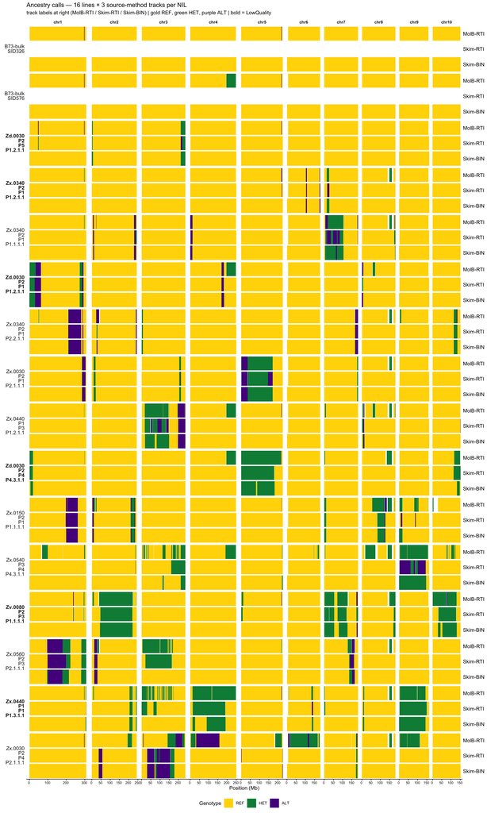

```r
paint3 <- bind_rows(
  as_paint(mb,   "MolB-RTI (r=2)"),
  as_paint(skim %>% filter(name %in% unique(mb$name)), "Skim-RTI (r=5)"),
  as_paint(gmm,  "Skim-BIN", numeric_state = FALSE)) %>%
  mutate(chr    = factor(chr, levels = 1:10, labels = paste0("chr", 1:10)),
         name   = factor(nil_lab(name), levels = nil_lab(ord)),
         method = factor(method, c("MolB-RTI (r=2)","Skim-RTI (r=5)","Skim-BIN")),
         ylo = case_when(method == "MolB-RTI (r=2)" ~ 0.69, method == "Skim-RTI (r=5)" ~ 0.35, TRUE ~ 0.00),
         yhi = case_when(method == "MolB-RTI (r=2)" ~ 1.00, method == "Skim-RTI (r=5)" ~ 0.66, TRUE ~ 0.32))

# per-track source-method label at each lane's y-midpoint (bottom -> top)
lane_mid <- c(0.16, 0.505, 0.845)
lane_lab <- c("Skim-BIN", "Skim-RTI", "MolB-RTI")
ggplot(paint3, aes(xmin = start_bp/1e6, xmax = end_bp/1e6,
                   ymin = ylo, ymax = yhi, fill = state)) +
  geom_rect() +
  facet_grid(name ~ chr, scales = "free_x", space = "free_x", switch = "y") +
  scale_fill_manual(values = pal, drop = FALSE) +
  scale_x_continuous(labels = scales::unit_format(unit = "", scale = 1)) +
  scale_y_continuous(breaks = lane_mid, labels = lane_lab,
                     expand = expansion(mult = 0.02), position = "right") +
  labs(title = "Ancestry calls — 16 lines × 3 source-method tracks per NIL",
       subtitle = "track labels at right (MolB-RTI / Skim-RTI / Skim-BIN) | gold REF, green HET, purple ALT | bold = LowQuality",
       x = "Position (Mb)", fill = "Genotype") +
  ggpubr::theme_classic2(base_size = 9) +
  theme(legend.position = "bottom",
        strip.background = element_blank(),
        strip.text.x = element_text(face = "bold"),
        # NIL name rotated 90° CCW (vertical) at the far left of each row group
        strip.text.y.left = ggtext::element_markdown(angle = 0, hjust = 1, size = 9, lineheight = 0.85),
        panel.spacing.x = unit(0.05, "lines"),
        panel.spacing.y = unit(0.05, "lines"),
        # per-track source-method label, horizontal, to the RIGHT of each genome track
        axis.text.y.right = element_text(size = 9), axis.ticks.y = element_blank(),
        axis.title.y = element_blank(), axis.line.y = element_blank(),
        axis.text.x = element_text(size = 6))
```

**Read:** the two skim lanes (Skim-RTI, Skim-BIN) are near-copies of each other and both sit **below** the MolB-RTI lane. The Skim/MolB gap is a platform effect reproduced by two independent skim callers, not a single-caller artifact. `PN4_SID330` is the lone sample where the two skim lanes agree with each other but **disagree in pattern** with MolB-RTI — the sample-identity swap flagged in `molbreeding_vs_skim_calibrated.qmd`.

## Donor genome-fraction — the three callers quantified

```r
frac <- function(seg, lab, numeric_state = TRUE) {
  st <- if (numeric_state) seg$state > 0 else seg$state != "REF"
  het <- if (numeric_state) seg$state == 1 else seg$state == "HET"
  seg %>% mutate(mb = (end_bp - start_bp)/1e6, donor = st, is_het = het) %>%
    group_by(name) %>%
    summarise(!!paste0(lab,"_donor") := sum(mb[donor])/sum(mb),
              !!paste0(lab,"_het")   := sum(mb[is_het])/sum(mb), .groups = "drop")
}
tab <- frac(mb, "MolB-RTI") %>%
  left_join(frac(skim %>% filter(name %in% unique(mb$name)), "Skim-RTI"), by = "name") %>%
  left_join(frac(gmm, "Skim-BIN", numeric_state = FALSE), by = "name") %>%
  arrange(`MolB-RTI_donor`) %>%
  mutate(NIL = ped_of(name), .before = 1) %>% select(-name)   # NIL = pedigree id
knitr::kable(tab, digits = 3)
```

| NIL | MolB-RTI_donor | MolB-RTI_het | Skim-RTI_donor | Skim-RTI_het | Skim-BIN_donor | Skim-BIN_het |
| --- | --- | --- | --- | --- | --- | --- |
| B73-bulk_SID326 | 0.001 | 0.000 | NA | NA | 0.000 | 0.000 |
| Zd.0030_P2_P5_P1.2.1.1 | 0.018 | 0.014 | 0.015 | 0.011 | 0.015 | 0.015 |
| Zx.0340_P2_P1_P1.2.1.1 | 0.019 | 0.013 | 0.011 | 0.000 | 0.011 | 0.007 |
| B73-bulk_SID576 | 0.026 | 0.024 | NA | NA | 0.000 | 0.000 |
| Zx.0340_P2_P1_P1.1.1.1 | 0.072 | 0.051 | 0.063 | 0.025 | 0.061 | 0.045 |
| Zx.0340_P2_P1_P2.2.1.1 | 0.075 | 0.022 | 0.059 | 0.014 | 0.060 | 0.014 |
| Zd.0030_P2_P1_P1.2.1.1 | 0.081 | 0.055 | 0.048 | 0.022 | 0.049 | 0.022 |
| Zx.0030_P2_P1_P2.1.1.1 | 0.109 | 0.084 | 0.100 | 0.062 | 0.101 | 0.075 |
| Zx.0150_P2_P1_P1.1.1.1 | 0.128 | 0.084 | 0.077 | 0.034 | 0.078 | 0.040 |
| Zx.0440_P1_P3_P1.2.1.1 | 0.130 | 0.109 | 0.085 | 0.042 | 0.080 | 0.059 |
| Zd.0030_P2_P4_P4.3.1.1 | 0.168 | 0.168 | 0.111 | 0.111 | 0.095 | 0.095 |
| Zx.0560_P2_P3_P2.1.1.1 | 0.184 | 0.128 | 0.160 | 0.094 | 0.090 | 0.039 |
| Zx.0540_P3_P4_P4.3.1.1 | 0.218 | 0.218 | 0.103 | 0.050 | 0.086 | 0.086 |
| Zv.0080_P2_P3_P1.1.1.1 | 0.233 | 0.225 | 0.191 | 0.191 | 0.182 | 0.179 |
| Zx.0440_P1_P1_P1.3.1.1 | 0.252 | 0.252 | 0.194 | 0.189 | 0.141 | 0.141 |
| Zx.0030_P2_P4_P2.1.1.1 | 0.289 | 0.200 | 0.083 | 0.021 | 0.081 | 0.018 |

```r
cat("\nmeans (NILs only, B73 checks dropped):\n")
```

```
means (NILs only, B73 checks dropped):
```

```r
tab %>% filter(!grepl("B73-bulk", NIL)) %>%
  summarise(across(where(is.numeric), ~round(mean(., na.rm = TRUE), 3))) %>%
  knitr::kable()
```

| MolB-RTI_donor | MolB-RTI_het | Skim-RTI_donor | Skim-RTI_het | Skim-BIN_donor | Skim-BIN_het |
| --- | --- | --- | --- | --- | --- |
| 0.141 | 0.116 | 0.093 | 0.062 | 0.081 | 0.059 |

## Two-way — MolB-RTI vs Skim-BIN

The MolB-vs-Skim comparison through the BIN caller alone (top = MolB-RTI (r=2), bottom = Skim-BIN), the Skim-BIN analog of the Skim-RTI two-way figure in `molbreeding_vs_skim_calibrated.qmd`.

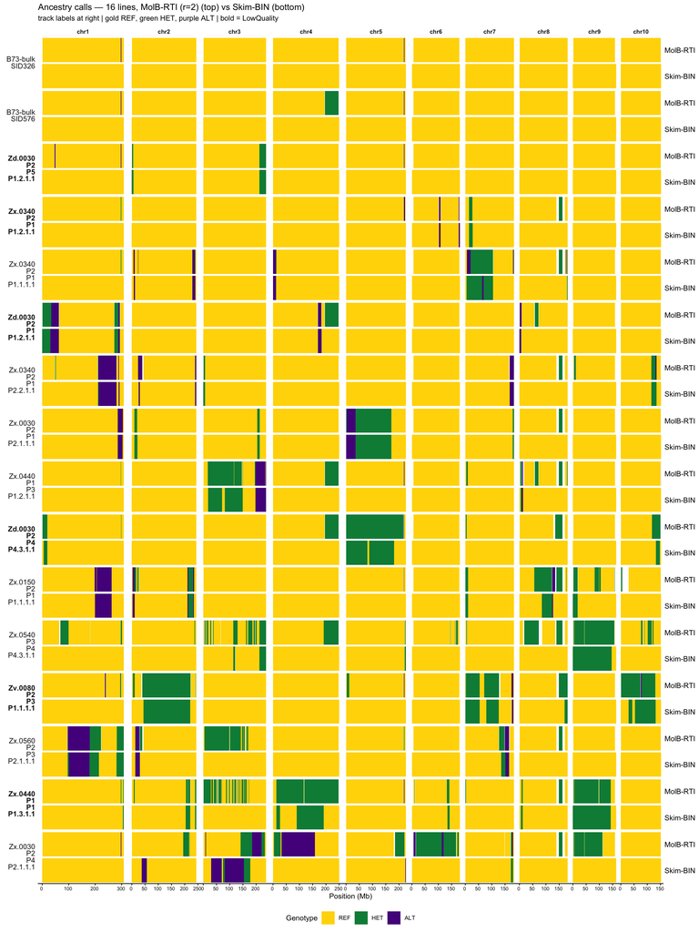

```r
paint2 <- bind_rows(
  as_paint(mb, "MolB-RTI (r=2)"),
  as_paint(gmm, "Skim-BIN", numeric_state = FALSE)) %>%
  mutate(chr    = factor(chr, levels = 1:10, labels = paste0("chr", 1:10)),
         name   = factor(nil_lab(name), levels = nil_lab(ord)),
         ylo = if_else(method == "MolB-RTI (r=2)", 0.52, 0.00),
         yhi = if_else(method == "MolB-RTI (r=2)", 1.00, 0.48))

# per-track source-method label at each lane's y-midpoint (bottom -> top)
lane_mid <- c(0.24, 0.76)
lane_lab <- c("Skim-BIN", "MolB-RTI")
ggplot(paint2, aes(xmin = start_bp/1e6, xmax = end_bp/1e6,
                   ymin = ylo, ymax = yhi, fill = state)) +
  geom_rect() +
  facet_grid(name ~ chr, scales = "free_x", space = "free_x", switch = "y") +
  scale_fill_manual(values = pal, drop = FALSE) +
  scale_x_continuous(labels = scales::unit_format(unit = "", scale = 1)) +
  scale_y_continuous(breaks = lane_mid, labels = lane_lab,
                     expand = expansion(mult = 0.02), position = "right") +
  labs(title = "Ancestry calls — 16 lines, MolB-RTI (r=2) (top) vs Skim-BIN (bottom)",
       subtitle = "track labels at right | gold REF, green HET, purple ALT | bold = LowQuality",
       x = "Position (Mb)", fill = "Genotype") +
  ggpubr::theme_classic2(base_size = 9) +
  theme(legend.position = "bottom",
        strip.background = element_blank(),
        strip.text.x = element_text(face = "bold"),
        # NIL name rotated 90° CCW (vertical) at the far left of each row group
        strip.text.y.left = ggtext::element_markdown(angle = 0, hjust = 1, size = 9, lineheight = 0.85),
        panel.spacing.x = unit(0.05, "lines"),
        panel.spacing.y = unit(0.05, "lines"),
        # per-track source-method label, horizontal, to the RIGHT of each genome track
        axis.text.y.right = element_text(size = 9), axis.ticks.y = element_blank(),
        axis.title.y = element_blank(), axis.line.y = element_blank(),
        axis.text.x = element_text(size = 6))
```

## Notes

- Skim-BIN calls staged from the BzeaSeq pipeline output `all_samples_ancestry_segments.bed` (the lab-meeting call set) to `data/bzeaseq_ancestry/gmm_hmm_segments_16lines.tsv`; not recomputed here.
- Skim-BIN and Skim-RTI run on the **same skim reads** (different filters + callers); their close agreement is an independent check that the MolB-vs-Skim divergence is not a caller artifact.